# PML Course Project

Scott Harrison

Sunday, June 21, 2015

This is the training data pull. I’ve reduced the size of the training set to improve running time. The full set takes a longer time to execute, but ulitimately, that will give better prediction results, but for demonstration purposes, a reduced training set still performs well.

```r
fileURL <- "https://d396qusza40orc.cloudfront.net/predmachlearn/pml-training.csv"
download.file(fileURL, destfile = "train.csv", method = "curl")
trainingRaw <- read.csv("train.csv",
                        na.strings = c("NA", "#DIV/0!", " ", ""))
#Reduce Sample Size
set.seed(1028)
sample <- sample(c(1:nrow(trainingRaw)),
                 nrow(trainingRaw) / 10,
                 replace = FALSE)

trainingRaw <- trainingRaw[sample, ]
```

```r
col_NAs <- colSums(is.na(trainingRaw))
NA_thresh <- 0.75
removeCols <- c(1:7, unname(which(col_NAs > NA_thresh)))

inTrain <- createDataPartition(trainingRaw$classe,
                               p = 0.75,
                               list = FALSE)

training <- trainingRaw[inTrain, -removeCols]
validate <- trainingRaw[-inTrain, -removeCols]
```

Originally, I did some exploratory data analysis and found columns that had good data. These looked interesting.

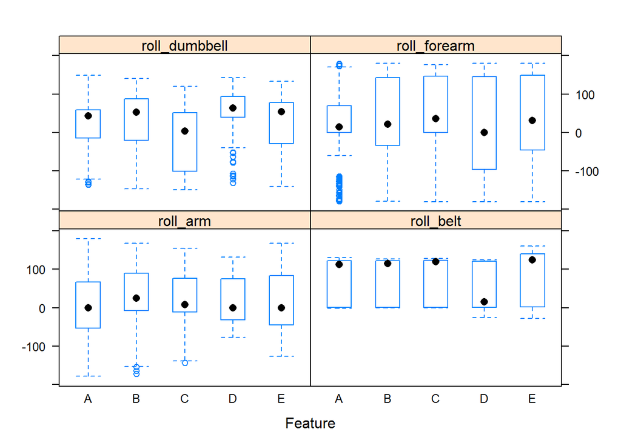

```r
rollCols <- grep("^roll_", names(training))
featurePlot(training[rollCols], training$classe, "box")
```

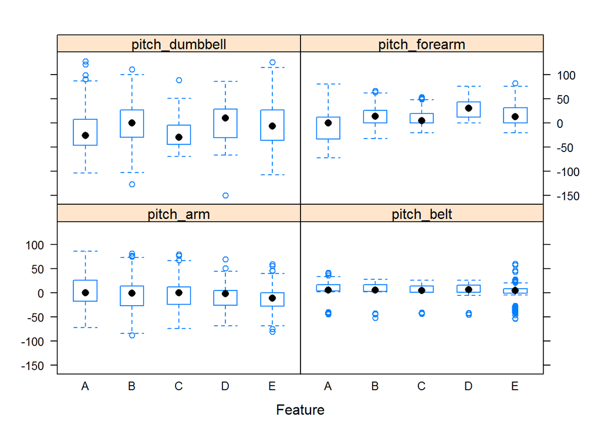

```r
pitchCols <- grep("^pitch_", names(training))
featurePlot(training[pitchCols], training$classe, "box")
```

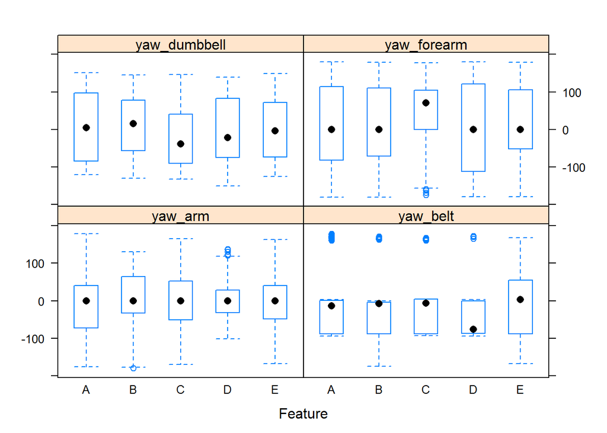

```r
yawCols <- grep("^yaw_", names(training))
featurePlot(training[yawCols], training$classe, "box")
```

```r
allCols <- c(rollCols, pitchCols, yawCols)
```

After building the model, the results were not great with a little over 47% accuracy. This model was not acceptable and it was hard to find other ways to improve the model.

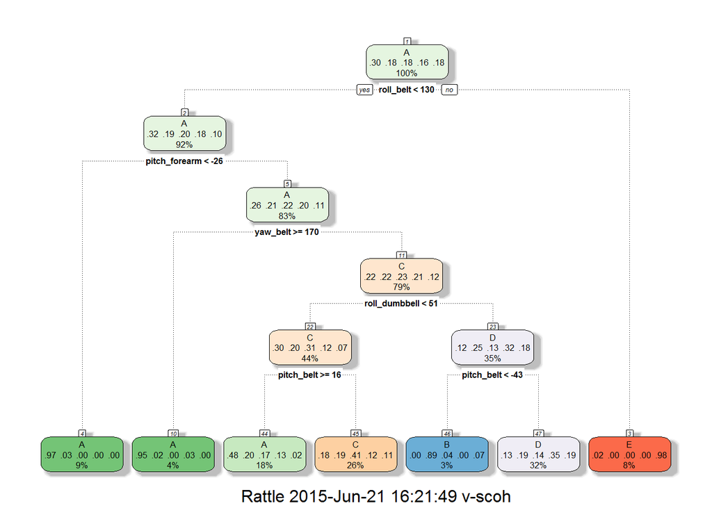

```r
modFit1 <- train(training$classe ~ ., method = "rpart", data = training[, allCols])
fancyRpartPlot(modFit1$finalModel)
```

```r
prediction <- predict(modFit1, validate[, allCols])
confusionMatrix (prediction, validate$classe)
```

```
## Confusion Matrix and Statistics
##
##           Reference
## Prediction  A  B  C  D  E
##          A 93 22 17 17  2
##          B  0  9  0  0  0
##          C 23 34 51 16 12
##          D 27 21 22 48 40
##          E  2  0  0  0 33
##
## Overall Statistics
##
##                Accuracy : 0.4785
##                  95% CI : (0.4335, 0.5238)
##     No Information Rate : 0.2965
##     P-Value [Acc > NIR] : < 2.2e-16
##
##                   Kappa : 0.338
##  Mcnemar's Test P-Value : NA
##
## Statistics by Class:
##
##                      Class: A Class: B Class: C Class: D Class: E
## Sensitivity            0.6414   0.1047   0.5667  0.59259  0.37931
## Specificity            0.8314   1.0000   0.7870  0.73039  0.99502
## Pos Pred Value         0.6159   1.0000   0.3750  0.30380  0.94286
## Neg Pred Value         0.8462   0.8396   0.8895  0.90030  0.88106
## Prevalence             0.2965   0.1759   0.1840  0.16564  0.17791
## Detection Rate         0.1902   0.0184   0.1043  0.09816  0.06748
## Detection Prevalence   0.3088   0.0184   0.2781  0.32311  0.07157
## Balanced Accuracy      0.7364   0.5523   0.6768  0.66149  0.68717
```

Random Forrests do the variable testing for us. The data is broken into 75% training and 25% validate, which would correlate with a 60% training, 20% validate, and 20% testing. In this case we have a smaller test set, but the validation set is a good way to test the random forrest model. This model does much better.

```r
modFitRF1 <- train(classe ~ .,
                  data = training,
                  method = "rf",
                  prox = TRUE,
                  allowParallel = TRUE)
modFitRF1
```

```
## Random Forest
##
## 1473 samples
##   52 predictor
##    5 classes: 'A', 'B', 'C', 'D', 'E'
##
## No pre-processing
## Resampling: Bootstrapped (25 reps)
##
## Summary of sample sizes: 1473, 1473, 1473, 1473, 1473, 1473, ...
##
## Resampling results across tuning parameters:
##
##   mtry  Accuracy   Kappa      Accuracy SD  Kappa SD
##    2    0.9010108  0.8739172  0.01178010   0.01514367
##   27    0.9044108  0.8783514  0.01239905   0.01581942
##   52    0.8910530  0.8614083  0.01554880   0.01967932
##
## Accuracy was used to select the optimal model using  the largest value.
## The final value used for the model was mtry = 27.
```

```r
prediction <- predict(modFitRF1, validate)
confusionMatrix (prediction, validate$classe)
```

```
## Confusion Matrix and Statistics
##
##           Reference
## Prediction   A   B   C   D   E
##          A 142   6   0   0   0
##          B   0  76   3   0   4
##          C   1   4  87   6   3
##          D   2   0   0  74   4
##          E   0   0   0   1  76
##
## Overall Statistics
##
##                Accuracy : 0.9305
##                  95% CI : (0.9042, 0.9514)
##     No Information Rate : 0.2965
##     P-Value [Acc > NIR] : < 2.2e-16
##
##                   Kappa : 0.9117
##  Mcnemar's Test P-Value : NA
##
## Statistics by Class:
##
##                      Class: A Class: B Class: C Class: D Class: E
## Sensitivity            0.9793   0.8837   0.9667   0.9136   0.8736
## Specificity            0.9826   0.9826   0.9649   0.9853   0.9975
## Pos Pred Value         0.9595   0.9157   0.8614   0.9250   0.9870
## Neg Pred Value         0.9912   0.9754   0.9923   0.9829   0.9733
## Prevalence             0.2965   0.1759   0.1840   0.1656   0.1779
## Detection Rate         0.2904   0.1554   0.1779   0.1513   0.1554
## Detection Prevalence   0.3027   0.1697   0.2065   0.1636   0.1575
## Balanced Accuracy      0.9809   0.9332   0.9658   0.9494   0.9355
```

To improve on the above random forrest model, I created a new model on the entire training set. This time I introduced cross validation by specifying that in the trainControl() settings. This is the final model I used to evalute the actual test data. It was not perfect, but much better than the first model I tried.

```r
training <- trainingRaw[, -removeCols]
ctrl <- trainControl(method = "cv", number = 3)
modFitRF2 <- train(classe ~ .,
                  data = training,
                  method = "rf",
                  trControl = ctrl,
                  prox = TRUE,
                  allowParallel = TRUE)

modFitRF2
```

```
## Random Forest
##
## 1962 samples
##   52 predictor
##    5 classes: 'A', 'B', 'C', 'D', 'E'
##
## No pre-processing
## Resampling: Cross-Validated (3 fold)
##
## Summary of sample sizes: 1308, 1308, 1308
##
## Resampling results across tuning parameters:
##
##   mtry  Accuracy   Kappa      Accuracy SD  Kappa SD
##    2    0.9260958  0.9060766  0.008421362  0.010724964
##   27    0.9286442  0.9093723  0.007226018  0.009318830
##   52    0.9245668  0.9041767  0.003848030  0.005067181
##
## Accuracy was used to select the optimal model using  the largest value.
## The final value used for the model was mtry = 27.
```

Final test script below. The expected error rate is less than 10%.

```r
fileURL <- "https://d396qusza40orc.cloudfront.net/predmachlearn/pml-testing.csv"
download.file(fileURL, destfile = "test.csv", method = "curl")
testingRaw <- read.csv("test.csv",
                       na.strings = c("NA", "#DIV/0!", " "))
testing <- testingRaw[, -removeCols]


prediction <- predict(modFitRF2, testing)
```

Generate test file script.

```r
pml_write_files = function(x){
  n = length(x)
  for(i in 1:n){
    filename = paste0("problem_id_",i,".txt")
    write.table(x[i],file=filename,quote=FALSE,row.names=FALSE,col.names=FALSE)
  }
}
pml_write_files(prediction)
```